# Carrefour Customer dataset Analysis- PCA

### Specifying the question

To make observations that may provide insights on how to maximize product sales.

### Defining the metrics of success

To term my analysis successful I should have been able to perform PCA and obtain the features responsible for most of the variation in the data and perform feature selection.

### Context

The data consists of customer records identifiable by ID, detailing products they purchased at a supermarket. The data consists of the following variables:

- Invoice.ID
- Branch of supermarket
- Customer.type
- Gender
- Product.line
- Unit.price
- Quantity
- Tax
- Date
- Time
- Payment
- Cost of goods - cogs
- Gross margin percentage
- Gross income
- Rating
- Total

## Loading the data

```r
supermarket <- read.csv("http://bit.ly/CarreFourDataset")
head(supermarket)
```

```
##    Invoice.ID Branch Customer.type Gender           Product.line Unit.price
## 1 750-67-8428      A        Member Female      Health and beauty      74.69
## 2 226-31-3081      C        Normal Female Electronic accessories      15.28
## 3 631-41-3108      A        Normal   Male     Home and lifestyle      46.33
## 4 123-19-1176      A        Member   Male      Health and beauty      58.22
## 5 373-73-7910      A        Normal   Male      Sports and travel      86.31
## 6 699-14-3026      C        Normal   Male Electronic accessories      85.39
##   Quantity     Tax      Date  Time     Payment   cogs gross.margin.percentage
## 1        7 26.1415  1/5/2019 13:08     Ewallet 522.83                4.761905
## 2        5  3.8200  3/8/2019 10:29        Cash  76.40                4.761905
## 3        7 16.2155  3/3/2019 13:23 Credit card 324.31                4.761905
## 4        8 23.2880 1/27/2019 20:33     Ewallet 465.76                4.761905
## 5        7 30.2085  2/8/2019 10:37     Ewallet 604.17                4.761905
## 6        7 29.8865 3/25/2019 18:30     Ewallet 597.73                4.761905
##   gross.income Rating    Total
## 1      26.1415    9.1 548.9715
## 2       3.8200    9.6  80.2200
## 3      16.2155    7.4 340.5255
## 4      23.2880    8.4 489.0480
## 5      30.2085    5.3 634.3785
## 6      29.8865    4.1 627.6165
```

## Checking the data

```r
# previewing the tail of the data set
tail(supermarket)
```

```
##       Invoice.ID Branch Customer.type Gender           Product.line Unit.price
## 995  652-49-6720      C        Member Female Electronic accessories      60.95
## 996  233-67-5758      C        Normal   Male      Health and beauty      40.35
## 997  303-96-2227      B        Normal Female     Home and lifestyle      97.38
## 998  727-02-1313      A        Member   Male     Food and beverages      31.84
## 999  347-56-2442      A        Normal   Male     Home and lifestyle      65.82
## 1000 849-09-3807      A        Member Female    Fashion accessories      88.34
##      Quantity     Tax      Date  Time Payment   cogs gross.margin.percentage
## 995         1  3.0475 2/18/2019 11:40 Ewallet  60.95                4.761905
## 996         1  2.0175 1/29/2019 13:46 Ewallet  40.35                4.761905
## 997        10 48.6900  3/2/2019 17:16 Ewallet 973.80                4.761905
## 998         1  1.5920  2/9/2019 13:22    Cash  31.84                4.761905
## 999         1  3.2910 2/22/2019 15:33    Cash  65.82                4.761905
## 1000        7 30.9190 2/18/2019 13:28    Cash 618.38                4.761905
##      gross.income Rating     Total
## 995        3.0475    5.9   63.9975
## 996        2.0175    6.2   42.3675
## 997       48.6900    4.4 1022.4900
## 998        1.5920    7.7   33.4320
## 999        3.2910    4.1   69.1110
## 1000      30.9190    6.6  649.2990
```

```r
# checking for the dimensions of my data
dim(supermarket)
```

```
## [1] 1000   16
```

```r
# checking for my column data types
str(supermarket)
```

```
## 'data.frame':    1000 obs. of  16 variables:
##  $ Invoice.ID             : chr  "750-67-8428" "226-31-3081" "631-41-3108" "123-19-1176" ...
##  $ Branch                 : chr  "A" "C" "A" "A" ...
##  $ Customer.type          : chr  "Member" "Normal" "Normal" "Member" ...
##  $ Gender                 : chr  "Female" "Female" "Male" "Male" ...
##  $ Product.line           : chr  "Health and beauty" "Electronic accessories" "Home and lifestyle" "Health and beauty" ...
##  $ Unit.price             : num  74.7 15.3 46.3 58.2 86.3 ...
##  $ Quantity               : int  7 5 7 8 7 7 6 10 2 3 ...
##  $ Tax                    : num  26.14 3.82 16.22 23.29 30.21 ...
##  $ Date                   : chr  "1/5/2019" "3/8/2019" "3/3/2019" "1/27/2019" ...
##  $ Time                   : chr  "13:08" "10:29" "13:23" "20:33" ...
##  $ Payment                : chr  "Ewallet" "Cash" "Credit card" "Ewallet" ...
##  $ cogs                   : num  522.8 76.4 324.3 465.8 604.2 ...
##  $ gross.margin.percentage: num  4.76 4.76 4.76 4.76 4.76 ...
##  $ gross.income           : num  26.14 3.82 16.22 23.29 30.21 ...
##  $ Rating                 : num  9.1 9.6 7.4 8.4 5.3 4.1 5.8 8 7.2 5.9 ...
##  $ Total                  : num  549 80.2 340.5 489 634.4 ...
```

## Data cleaning

```r
# checking for missing values
colSums(is.na(supermarket))
```

```
##              Invoice.ID                  Branch           Customer.type
##                       0                       0                       0
##                  Gender            Product.line              Unit.price
##                       0                       0                       0
##                Quantity                     Tax                    Date
##                       0                       0                       0
##                    Time                 Payment                    cogs
##                       0                       0                       0
## gross.margin.percentage            gross.income                  Rating
##                       0                       0                       0
##                   Total
##                       0
```

There are no missing values in my data frame.

```r
# checking for duplicates in my data frame
supermarket[duplicated(supermarket), ]
```

```
##  [1] Invoice.ID              Branch                  Customer.type
##  [4] Gender                  Product.line            Unit.price
##  [7] Quantity                Tax                     Date
## [10] Time                    Payment                 cogs
## [13] gross.margin.percentage gross.income            Rating
## [16] Total
## <0 rows> (or 0-length row.names)
```

There are no duplicates in my data frame

```r
# Converting the date and time columns into date time data type format
supermarket$Date <- as.Date(supermarket$Date, format = "%m/%d/%y")

# merging the two columns time and date
supermarket$Date.Time <- paste(supermarket$Date, supermarket$Time)

# converting to date time data type
supermarket$Date.Time <- as.POSIXct(supermarket$Date.Time)
```

```r
# checking the unique values categorical for my data frame variables
unique(supermarket$Branch)
```

```
## [1] "A" "C" "B"
```

```r
unique(supermarket$Customer.type)
```

```
## [1] "Member" "Normal"
```

```r
unique(supermarket$Gender)
```

```
## [1] "Female" "Male"
```

```r
unique(supermarket$Product.line)
```

```
## [1] "Health and beauty"      "Electronic accessories" "Home and lifestyle"
## [4] "Sports and travel"      "Food and beverages"     "Fashion accessories"
```

```r
unique(supermarket$Payment)
```

```
## [1] "Ewallet"     "Cash"        "Credit card"
```

```r
range(supermarket$gross.margin.percentage)
```

```
## [1] 4.761905 4.761905
```

The value for all the records for the gross margin percentage variable is the same hence this variable will not be useful in my analysis and will be dropped as a result.

```r
# hot encoding my categorical variables

cat <- supermarket[ , c("Branch", "Gender", "Product.line", "Customer.type", "Payment")]

dummies <- dummyVars(~ ., data = cat)
df_dummies <- as.data.frame(predict(dummies, newdata = cat))

head(df_dummies)
```

```
##   BranchA BranchB BranchC GenderFemale GenderMale
## 1       1       0       0            1          0
## 2       0       0       1            1          0
## 3       1       0       0            0          1
## 4       1       0       0            0          1
## 5       1       0       0            0          1
## 6       0       0       1            0          1
##   Product.lineElectronic accessories Product.lineFashion accessories
## 1                                  0                               0
## 2                                  1                               0
## 3                                  0                               0
## 4                                  0                               0
## 5                                  0                               0
## 6                                  1                               0
##   Product.lineFood and beverages Product.lineHealth and beauty
```

[output cut: 27 more lines]

```r
# merging with my original data frame

Supermarket <- cbind(supermarket, df_dummies)
head(Supermarket)
```

```
##    Invoice.ID Branch Customer.type Gender           Product.line Unit.price
## 1 750-67-8428      A        Member Female      Health and beauty      74.69
## 2 226-31-3081      C        Normal Female Electronic accessories      15.28
## 3 631-41-3108      A        Normal   Male     Home and lifestyle      46.33
## 4 123-19-1176      A        Member   Male      Health and beauty      58.22
## 5 373-73-7910      A        Normal   Male      Sports and travel      86.31
## 6 699-14-3026      C        Normal   Male Electronic accessories      85.39
##   Quantity     Tax       Date  Time     Payment   cogs gross.margin.percentage
## 1        7 26.1415 2020-01-05 13:08     Ewallet 522.83                4.761905
## 2        5  3.8200 2020-03-08 10:29        Cash  76.40                4.761905
## 3        7 16.2155 2020-03-03 13:23 Credit card 324.31                4.761905
## 4        8 23.2880 2020-01-27 20:33     Ewallet 465.76                4.761905
## 5        7 30.2085 2020-02-08 10:37     Ewallet 604.17                4.761905
## 6        7 29.8865 2020-03-25 18:30     Ewallet 597.73                4.761905
##   gross.income Rating    Total           Date.Time BranchA BranchB BranchC
```

[output cut: 41 more lines]

After encoding the categorical columns with the actual values can now be dropped.

```r
# dropping of the unnecessary columns
to_drop <- c("Gender", "gross.margin.percentage", "Customer.type", "Branch", "Gender", "Product.line", "Payment", "Date", "Time")

Supermarket <- Supermarket[ , !names(Supermarket) %in% to_drop]
head(Supermarket)
```

```
##    Invoice.ID Unit.price Quantity     Tax   cogs gross.income Rating    Total
## 1 750-67-8428      74.69        7 26.1415 522.83      26.1415    9.1 548.9715
## 2 226-31-3081      15.28        5  3.8200  76.40       3.8200    9.6  80.2200
## 3 631-41-3108      46.33        7 16.2155 324.31      16.2155    7.4 340.5255
## 4 123-19-1176      58.22        8 23.2880 465.76      23.2880    8.4 489.0480
## 5 373-73-7910      86.31        7 30.2085 604.17      30.2085    5.3 634.3785
## 6 699-14-3026      85.39        7 29.8865 597.73      29.8865    4.1 627.6165
##             Date.Time BranchA BranchB BranchC GenderFemale GenderMale
## 1 2020-01-05 13:08:00       1       0       0            1          0
## 2 2020-03-08 10:29:00       0       0       1            1          0
## 3 2020-03-03 13:23:00       1       0       0            0          1
## 4 2020-01-27 20:33:00       1       0       0            0          1
## 5 2020-02-08 10:37:00       1       0       0            0          1
## 6 2020-03-25 18:30:00       0       0       1            0          1
##   Product.lineElectronic accessories Product.lineFashion accessories
```

[output cut: 34 more lines]

## Multivariate analysis

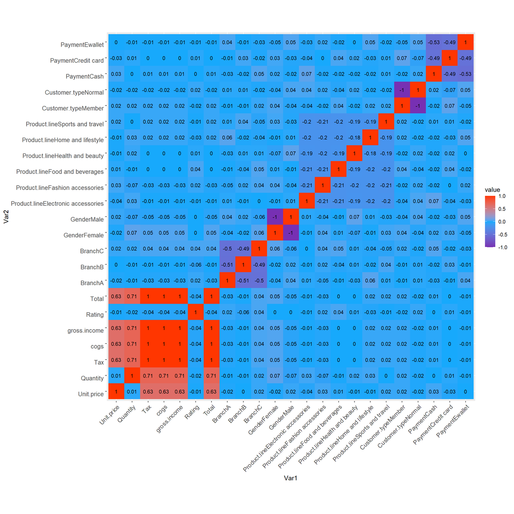

```r
data <- Supermarket[ ,-1] # excluding the ID variable

data <- subset(data, select = -c(Date.Time))

# computing the correlations for my data
correlations <- round(cor(data), 2)

# reshaping the correlations object by melting
melted <- melt(correlations, na.rm = FALSE)


# Plotting the correlations
ggplot(data = melted, aes(Var1, Var2, fill =value)) + geom_tile() + geom_text(aes(Var1, Var2, label =value), color = "black", size =3) + scale_fill_gradient2(low = "#7730B3", high = "#FF3600", mid = "#17A9FC", midpoint = 0) + theme(axis.text.x = element_text(angle = 45, vjust = 1,
    size = 10, hjust = 1), axis.text.y = element_text(vjust = 1, size = 10, hjust = 1))+
 coord_fixed()
```

## Feature selection

```r
# removing redundancy by spotting the most highly correlated features
high_cor <- findCorrelation(correlations, cutoff = 0.75)

high_cor_f <- names(data[ ,high_cor])

# removing the features with high correlations
data_ <- data[ , !names(data) %in% high_cor_f]
head(data_)
```

```
##   Unit.price Quantity Rating    Total BranchA BranchB BranchC GenderMale
## 1      74.69        7    9.1 548.9715       1       0       0          0
## 2      15.28        5    9.6  80.2200       0       0       1          0
## 3      46.33        7    7.4 340.5255       1       0       0          1
## 4      58.22        8    8.4 489.0480       1       0       0          1
## 5      86.31        7    5.3 634.3785       1       0       0          1
## 6      85.39        7    4.1 627.6165       0       0       1          1
##   Product.lineElectronic accessories Product.lineFashion accessories
## 1                                  0                               0
## 2                                  1                               0
## 3                                  0                               0
## 4                                  0                               0
## 5                                  0                               0
## 6                                  1                               0
##   Product.lineFood and beverages Product.lineHealth and beauty
```

[output cut: 20 more lines]

## Dimensionality reduction

```r
# performing pca
data.pca <- prcomp(data_, center = TRUE, scale. = TRUE)

summary(data.pca)
```

```
## Importance of components:
##                           PC1     PC2     PC3     PC4     PC5    PC6     PC7
## Standard deviation     1.4064 1.27453 1.24702 1.22392 1.21666 1.1104 1.09561
## Proportion of Variance 0.1099 0.09025 0.08639 0.08322 0.08224 0.0685 0.06669
## Cumulative Proportion  0.1099 0.20013 0.28652 0.36974 0.45198 0.5205 0.58717
##                            PC8     PC9    PC10    PC11    PC12    PC13    PC14
## Standard deviation     1.09045 1.08446 1.08032 1.00915 0.99550 0.97538 0.93895
## Proportion of Variance 0.06606 0.06534 0.06484 0.05658 0.05506 0.05285 0.04898
## Cumulative Proportion  0.65323 0.71857 0.78341 0.83998 0.89504 0.94789 0.99687
##                           PC15      PC16      PC17      PC18
## Standard deviation     0.23722 1.018e-15 7.221e-16 6.665e-16
## Proportion of Variance 0.00313 0.000e+00 0.000e+00 0.000e+00
## Cumulative Proportion  1.00000 1.000e+00 1.000e+00 1.000e+00
```

The first pca component only accounts for 11 percent and for the second 9 percent of the variations in the data. The cumulative variation indicates that the first 15 components account for all the variation of the data.

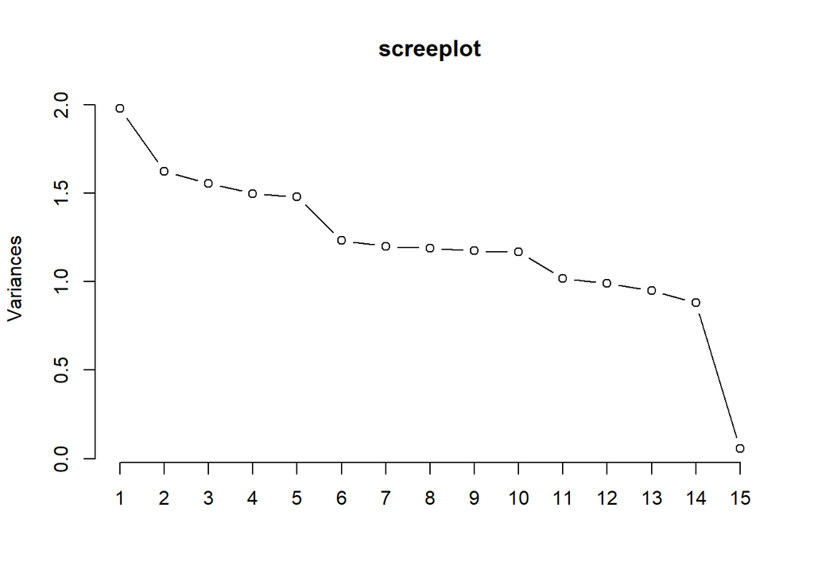

```r
# plotting a scree plots of my eigenvalues
screeplot(data.pca, type = "line", main = "screeplot", npcs = 15)
```

The percentage variation of the data after the fifth principal component drops and then majorly drops in the 15th principal component. The 15th principal component doesn’t contribute much to the overall variation present in the data.

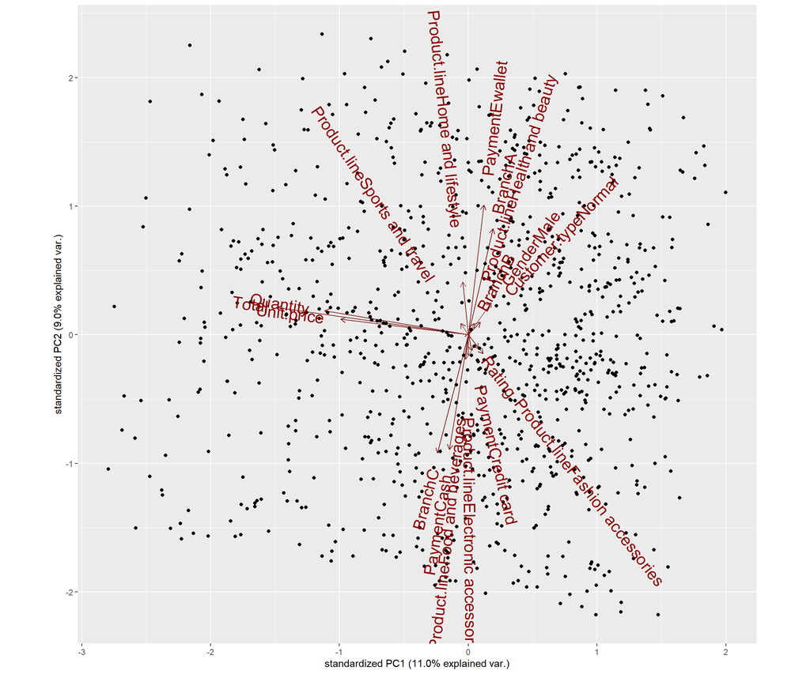

```r
# plotting the components
ggbiplot(data.pca, varname.size =6, varname.abbrev = FALSE)
```

From the plot we I am able to observe the following:

- The variables Quantity, total and unit price are the most important variables in terms of contribution to the first principal component.
- The variables for the type of payment and the supermarket branches are the most important variables in terms of contribution to the second principal component.
- The above variables are the ones most credited for the variations in the data as they exhibit the longest arrows.